# Customer_Segment

## Introduction

In this practice, I will explore how to visualize and analyze realistic customer behavior data using interactive plots.

Customers are grouped into three segments: High Value, Mid Value, and Low Value. These segments reflect varying levels of loyalty, frequency of purchase, and potential business value.

I'll visualize the dataset using a 3D scatter plot to observe how customers are distributed in behavioral space. Then, I'll use box plots and categorical bar charts to explore differences between segments by region and gender.

### Goal

The goal of this lab is to practice how to simulate, visualize, and interpret customer segmentation results in a business context. These techniques are commonly used in marketing analytics, CRM optimization, and targeted campaign strategies.

```python
!pip install numpy==2.2.0
!pip install pandas==2.2.3
!pip install matplotlib==3.9.3
!pip install plotly==5.24.1
!pip install umap-learn==0.5.7
```

[output not shown]

[output not shown]

[output not shown]

### Import the required libraries

```python
import numpy as np
import matplotlib.pyplot as plt
import pandas as pd
from sklearn.datasets import make_blobs
from sklearn.preprocessing import StandardScaler
import seaborn as sns

import umap.umap_ as UMAP
from sklearn.manifold import TSNE
from sklearn.decomposition import PCA

import plotly.express as px
from sklearn.datasets import make_blobs
```

### Generate synthetic data with three clusters in a 3D space

```python
# Set seed for reproducibility
np.random.seed(42)

# Define cluster centers for 3 segments
centers = [
    [85, 40, 9],   # High Value
    [60, 25, 6],   # Mid Value
    [35, 10, 3]    # Low Value
]
cluster_std = [5, 6, 8]

# Generate synthetic data
from sklearn.datasets import make_blobs
X, labels = make_blobs(n_samples=1000,
                       centers=centers,
                       cluster_std=cluster_std,
                       n_features=3,
                       random_state=42)

# Clip negative values
X = np.clip(X, a_min=0, a_max=None)

# Create base DataFrame
df = pd.DataFrame(X, columns=["Engagement_Score", "Purchase_Frequency", "Product_Interest"])
df["Segment"] = pd.Series(labels).map({0: "High Value", 1: "Mid Value", 2: "Low Value"})

# Add synthetic Region and Gender
regions = ["North", "South", "East", "West"]
genders = ["Male", "Female"]

df["Region"] = np.random.choice(regions, size=len(df), p=[0.25, 0.25, 0.25, 0.25])
df["Gender"] = np.random.choice(genders, size=len(df), p=[0.5, 0.5])

df.head()
```

|  | Engagement_Score | Purchase_Frequency | Product_Interest | Segment | Region | Gender |
| --- | --- | --- | --- | --- | --- | --- |
| 0 | 19.701960 | 9.450928 | 0.000000 | Low Value | South | Male |
| 1 | 72.375150 | 18.594803 | 6.145317 | Mid Value | West | Female |
| 2 | 83.556707 | 41.613593 | 4.863845 | High Value | East | Female |
| 3 | 61.346711 | 31.282590 | 16.103566 | Mid Value | East | Female |
| 4 | 82.552803 | 45.220804 | 12.409457 | High Value | North | Female |

### Display the data in an interactive Plotly 3D scatter plot

```python
fig = px.scatter_3d(df,
                    x='Engagement_Score',
                    y='Purchase_Frequency',
                    z='Product_Interest',
                    color='Segment',
                    opacity=0.7,
                    color_discrete_sequence=px.colors.qualitative.G10,
                    title="3D Scatter Plot of Customer Segments")

fig.update_layout(
    scene=dict(
        xaxis_title='Engagement Score (0–100)',
        yaxis_title='Purchase Frequency (0–50)',
        zaxis_title='Product Interest (0–10)'
    ),
    width=900,
    height=700
)

fig.update_traces(marker=dict(size=4, line=dict(width=0.5, color='black')), showlegend=True)
fig.show()
```

[interactive chart not shown]

### Visualizing Customer Segments by Key Attributes

To further explore the differences between customer groups, we visualize the segmentation distribution using box plots and bar charts.

These visualizations help uncover how customer segments vary in:

- Engagement Score
- Region
- Gender

#### 1. Box Plot: Engagement Score by Segment

This box plot helps us understand how engagement levels differ across customer segments. The spread, median, and potential outliers provide insight into behavioral variability.

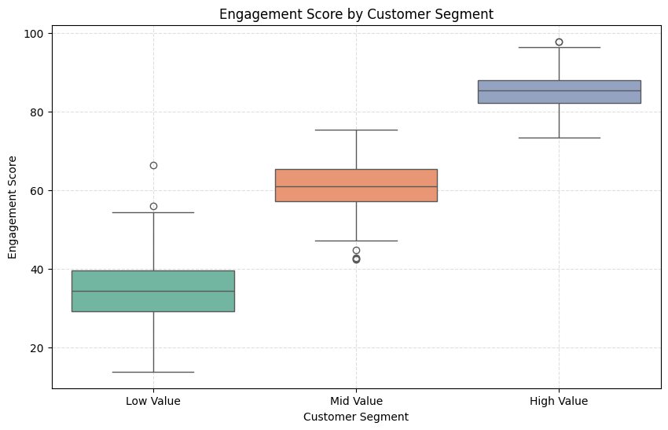

```python
plt.figure(figsize=(10, 6))
sns.boxplot(data=df, x='Segment', y='Engagement_Score', palette='Set2')
plt.title('Engagement Score by Customer Segment')
plt.ylabel('Engagement Score')
plt.xlabel('Customer Segment')
plt.grid(True, linestyle='--', alpha=0.4)
plt.show()
```

#### 2. Bar Chart: Customer Segment Distribution by Region

This bar chart shows how each customer segment is distributed across different regions. It can support targeting regional marketing campaigns or improving customer experience by location.

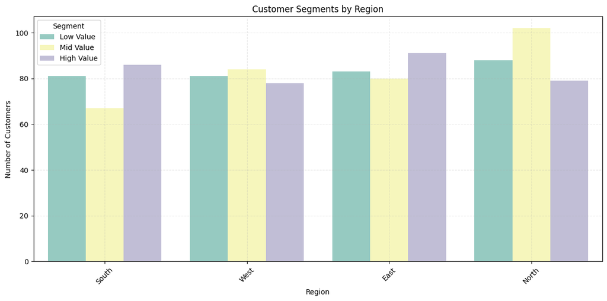

```python
plt.figure(figsize=(12, 6))
sns.countplot(data=df, x='Region', hue='Segment', palette='Set3')
plt.title('Customer Segments by Region')
plt.ylabel('Number of Customers')
plt.xlabel('Region')
plt.xticks(rotation=45)
plt.grid(True, linestyle='--', alpha=0.3)
plt.legend(title='Segment')
plt.tight_layout()
plt.show()
```

#### 3. Bar Chart: Customer Segment Distribution by Gender

This chart helps reveal if there's any gender skew across the three customer segments. Such insights can inform personalization strategies.

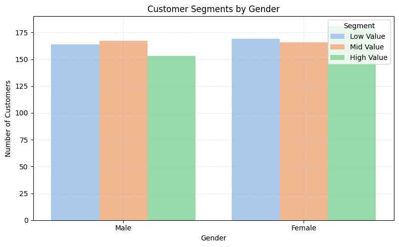

```python
plt.figure(figsize=(8, 5))
sns.countplot(data=df, x='Gender', hue='Segment', palette='pastel')
plt.title('Customer Segments by Gender')
plt.xlabel('Gender')
plt.ylabel('Number of Customers')
plt.grid(True, linestyle='--', alpha=0.3)
plt.legend(title='Segment')
plt.tight_layout()
plt.show()
```